# Assignment 5

**CS283 Computer Vision, Harvard University, Fall 2019**

**Due Wednesday, Oct. 16, at 5:00pm**

Name: Alexandra Kieras

Edges, corners, and multi-resolution representations are the topics covered in this assignment. As usual, the assignment will be submitted via canvas and formatted according to the guidelines.

```python
# Run this cell (only once) to install the unzip command.
# If you already installed this for previous assignments, no need to reinstall.
! sudo apt install unzip
```

```python
# Extract required pset folders (make sure you ran the first cell first)
! unzip pset5.zip
```

```python
# Import any required libraries here
import cv2                               # OpenCV
import numpy as np                       # numpy
import scipy.signal                      # Signal package from scipy for convolution
import scipy.interpolate                 # Interpolation, used for question 2
from mpl_toolkits.mplot3d import Axes3D  # 3D plotting, used for the code block in question 3

# Use this line to make matplotlib plot inline (only need to call it once when importing matplotlib)
%matplotlib inline

import matplotlib.pyplot as plt
# Modify this line to adjust the displayed plot size. You can also call
# it with different parameters before specific plots.
plt.rcParams['figure.figsize'] = [10, 10]
```

## Question 1 (10 points)

In class we derived a finite-difference approximation to the derivative of the univariate function $f(x)$ by considering the Taylor polynomial approximations of $f(x+ h)$ and $f(x-h)$. We showed that \begin{equation*} f'(x)=\frac{f(x+h)-f(x-h)}{2h}+O(h^2), \end{equation*} so that the derivative can be approximated by convolving a discrete version of $f(x)$—a vector of values $[\ldots,f(x_o-\Delta),\ f(x_o),\ f(x_o+\Delta),\ldots]$—with kernel $[1/2,0, -1/2]$. This is termed a *central difference* because its interval is symmetric about a sample point.

**a.** Derive a higher order central-difference approximation to $f'(x)$ such that the truncation error tends to zero as $h^4$ instead of $h^2$.

*Hint: consider Taylor polynomial approximations of $f(x\pm 2h)$ in addition to $f(x\pm h)$.*

### Answer:

We begin by expanding the Taylor series of $f(x \pm h)$, $f(x \pm 2h)$:

$$ f(x + h) = f(x) + f'(x) h + \frac{f^{''}h^2}{2!} + \frac{f^3(x)h^3}{3!} + \frac{f^4(x)h^4}{4!} + \frac{f^5(x)h^5}{5!} + R^1_5$$$$ f(x - h) = f(x) - f'(x) h + \frac{f^{''}h^2}{2!} - \frac{f^3(x)h^3}{3!} + \frac{f^4(x)h^4}{4!} - \frac{f^5(x)h^5}{5!} + R^2_5$$$$ f(x + 2h) = f(x) + 2f'(x) h + \frac{4f^{''}h^2}{2!} + \frac{8f^3(x)h^3}{3!} + \frac{16f^4(x)h^4}{4!} + \frac{32f^5(x)h^5}{5!} + R^3_5 $$$$ f(x - 2h) = f(x) - 2f'(x) h + \frac{4f^{''}h^2}{2!} - \frac{8f^3(x)h^3}{3!} + \frac{f^4(x)h^4}{4!} - \frac{16f^5(x)h^5}{5!} + R^4_5$$

Where $R^1_5, R^2_5, R^3_5, R^4_5$ are specific remainders indicating the rest of the Taylor series after the fifth term.

We then combine lines 1 and 2 and lines 3 and 4 to get:

$$ f(x + h) - f(x - h) = 2f'(x)h + \frac{2f^3(x)h^3}{3!} + \frac{2f^5(x)h^5}{5!} + R^5_5$$$$ f(x + 2h) - f(x - 2h) = 4f'(x)h + \frac{16f^3(x)h^3}{3!} + \frac{64f^5(x)}{5!} + R^6_5$$

where we notice that $R^5_5$ and $R^6_5$ contain only odd exponentials.

Then, we multiply the first equation by -8 in order to cancel the $f^3$ term, giving:

$$ f(x + 2h) - 8f(x + h) + 8f(x - h) - f(x - 2h) = -12f'(x)h + \frac{48f^5(x)h^5}{5!} - R^7_5$$$$ f(x + 2h) - 8f(x + h) + 8f(x - h) - f(x - 2h) - \frac{48f^5(x)h^5}{5!} + R^7_5 = -12f'(x)h$$$$ f'(x) = \frac{-f(x + 2h) + 8f(x + h) - 8f(x - h) + f(x - 2h)}{12h} + \frac{4f^5(x)h^4}{5!} - \frac{R^7_5}{12}$$

We see that as $h \to 0$, the $h^4$ term will dominate in size over the tail of the Taylor series, $\frac{R^7_5}{12}$, and so this gives us:

$$ f'(x) = \frac{-f(x + 2h) + 8f(x + h) - 8f(x - h) + f(x - 2h)}{12h} + O(h^4)$$

**b.** What is the corresponding convolution (not correlation!) kernel?

### Answer:

The convolution kernel is:

$$ \left[\begin{array}{ccccc} \frac{-1}{12} & \frac{2}{3} & 0 & \frac{-2}{3} & \frac{1}{12}\end{array}\right]$$

## Question 2 (20 points)

In this question you will build your own edge detectors with sub-pixel accuracy, borrowing heavily from Chapter Four of Szeliski. Your function,

`edgels()` takes an image `im` and a scale parameter `sigma` ($\sigma$) at which derivatives are computed. It should return two outputs: an $N\times 2$ array where each row stores the $(x,y)$ pixel coordinates of an "edgel", and an $N\times 2$ array with each row storing the corresponding gradient vector $(I_x, I_y)$ at the pixel location corresponding to each edgel. Substantial skeleton code for this problem can be found in the `edgels()` function below. To complete this function, you will need to write three parts:

- A helper function `deriv(sigma)` that takes a Gaussian width `sigma` and creates derivative-of-Gaussian kernels for horizontal and vertical derivatives. *Hint: check out the code for the existing helper function `lapgauss()`*
- For each quadruple of pixels, $\{(i,j),(i+1,j),(i,j+1),(i+1,j+1)\}$, code that checks if it is an edgel using the sign of the Laplacian-of-Gaussian filter applied to the image. A horizontal edgel has positive Laplacian-of-Gaussian values at the top two pixels and negative ones at the bottom ones (or vice versa), whereas a vertical edgel has positive values at the left two pixels and negative ones at the right ones (or vice versa). For each found edgel, the code must compute the two sub-pixel zero-crossing locations using Eq. 4.25 in Szeliski (make sure to check the code comments for a typo in this equation), and then the midpoint of these two zero-crossing locations as the final edgel location.
- For each edgel, code that samples the image gradient at the sub-pixel location using `scipy.interpolate.RegularGridInterpolator()`.

Validate your code by running it on the image `./data/calib_right.bmp`. Superimpose your detected edgels returned by `edgels()` on the image using the `matplotlib.pyplot.quiver()` function. Make sure the arrows are clearly visible and the figure is properly resized by setting the `'figure.figsize'` field of `plt.rcParams` (see code cell above Question 1). Some useful inputs to the [quiver function](https://matplotlib.org/3.1.1/api/_as_gen/matplotlib.pyplot.quiver.html) are `width`, `scale`, `headwidth`, `headlength`, `color` and `angles` (see note below).

Note: when calling `matplotlib.pyplot.quiver()` after `matplotlib.pyplot.imshow()` the y-axis of the image is pointing down but the y-axis of the quiver plot is pointing up. This can be fixed by either plotting the negative y-component of the gradient or by calling the quiver function with `angles='xy'`.

Use the text cell below to briefly explain your code. Additionally, comment every nontrivial part of your code.

### Answer:

This code first inspects all possible edgel locations, filtering them to create lists of vertical and horizontal edgels based on the LoG filter applied to the image.

Then, the code calculates the sub-pixel location for each edgel element. Following this, the code uses a RegularGridInterpolator to get the value of the image gradient at each edgel location, and displays the resulting vectors overlayed with the image.

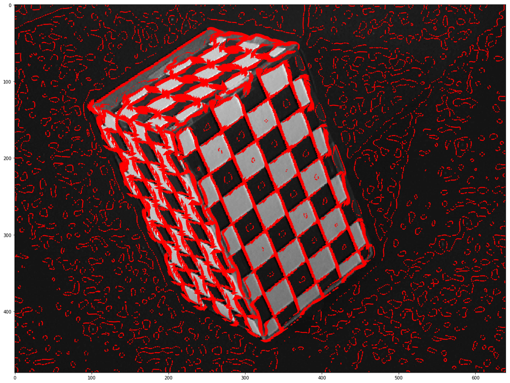

```python
def edgels(im, sigma):
    # check for vertical edgel
    def check_vert_cross(tup, log):
        x, y = tup
        if(log[x][y] * log[x+1][y] > 0):
            return ((log[x][y] * log[x][y+1] < 0) and (log[x+1][y] * log[x+1][y+1] < 0))
        return False

    # check for horizontal edgel
    def check_horiz_cross(tup, log):
        x, y = tup
        if(log[x][y] * log[x][y+1] > 0):
            return ((log[x][y] * log[x+1][y] < 0) and (log[x][y+1] * log[x+1][y+1] < 0))
        return False

    # get localization
    def loc(p1, p2, im_log):

        x1, y1 = p1
        x2, y2 = p2
        p1 = np.array(p1)
        p2 = np.array(p2)
        num = p1 * im_log[x2, y2] - p2*im_log[x1, y1]
        denom = im_log[x2, y2] - im_log[x1, y1]

        return num/denom

    # get loc for horizontal edgel
    def loch(val, im_log):
        x, y = val
        l1 = loc((x, y), (x+1, y), im_log)
        l2 = loc((x, y+1), (x+1, y+1), im_log)
        return (l1 + l2)/2

    # get loc for vertical edgel
    def locv(val, im_log):
        x, y = val
        l1 = loc((x, y), (x, y+1), im_log)
        l2 = loc((x+1, y), (x+1, y+1), im_log)
        return (l1 + l2)/2



    """Edge detector based on Laplacian of Gaussian
      x, g = edgels(im, sigma) computes edges in image im at the scale given by
      the scalar value sigma. sigma is the standard deviation (in pixels) of
      the Gaussian filters used to computed first and second derivatives in
      the image.

      The output x is an Nx2 array, where each row is the (x,y) position of an
      edge point (or 'edgel'). Edgels are localized to sub-pixel accuracy, so
      these coordinates are not generally integers. The output g is another
      Nx2 array that stores the gradient vector at each edge point.

      The norm of each row of dx provides the gradient magnitudes, for example, and
      edgels with small gradient magnitudes can be removed as a post-process,
      by performing additional operations on the x, g returned by this function.

      Reference:
       ----------
       Closely related to the algorithm described in Chapter Four of R.
       Szeliski, "Computer Vision: Algorithms and Applications", available in
       draft form at http://research.microsoft.com/en-us/um/people/szeliski/Book/

    """

    # convert image to np.float32 and grayscale (so intensity values are in [0,1])
    if len(im.shape) > 2 and im.shape[2] == 3:
        im = cv2.cvtColor(im, cv2.COLOR_BGR2GRAY)

    im = np.float32(im) / 255.0


    # LoG response
    im_log = scipy.signal.convolve2d(im, lapgauss(sigma), 'same', boundary='symm')

    # Locate the four-pixel squares having exactly two
    #   zero-crossings along their four pair-wise connections

    # get all possible edgel locations to check
    Y, X = np.meshgrid(np.linspace(0, im_log.shape[1] - 2, im_log.shape[1]-1), np.linspace(0, im_log.shape[0] - 2, im_log.shape[0] - 1))
    Y = Y.astype(int)
    X = X.astype(int)
    pixels = np.array([X.flatten(), Y.flatten()]).transpose()

    # get horizontal and vertical edgels
    horiz_cross = np.array([val for val in pixels if check_horiz_cross(val, im_log)])
    vert_cross = np.array([val for val in pixels if check_vert_cross(val, im_log)])

    # get sub-pixel localizations for edgels
    h_loc = np.array([loch(val, im_log) for val in horiz_cross])
    v_loc = np.array([locv(val, im_log) for val in vert_cross])
    pix_locs = np.concatenate((h_loc, v_loc))

    # sample gradient at edgels
    gradx, grady = deriv(sigma)
    im_gradx = scipy.signal.convolve2d(im, gradx, 'same', boundary='symm')
    im_grady = scipy.signal.convolve2d(im, grady, 'same', boundary='symm')

    # Get interpolators for x, y gradient components
    Ix = scipy.interpolate.RegularGridInterpolator((np.arange(im_gradx.shape[0]), np.arange(im_gradx.shape[1])),
                                                         im_gradx, bounds_error=False, fill_value=np.nan)
    Iy = scipy.interpolate.RegularGridInterpolator((np.arange(im_grady.shape[0]), np.arange(im_grady.shape[1])),
                                                         im_grady, bounds_error=False, fill_value=np.nan)

    # Interpolate I to get intensity values at image points Xh.
    # Note: the way interpolator is defined is using (y,x)-pixel coordinates so we need to swap x and y in Xh
    Gx = Ix(pix_locs[:, :])
    Gy = Iy(pix_locs[:, :])

    # return values
    G = np.array([Gx, Gy]).transpose()
    return pix_locs, G

def deriv(sigma):
    """Create derivative-of-Gaussian kernels for horizontal and vertical derivatives.
    Input sigma is the standard deviation of the Gaussian. Use equation 4.21
    in the Szelsiki book. Note that the equation has a typo; the multiplicative
    factor 1/sigma^3 should insead be 1/sigma^4; this does not affect the results
    though.
    """

    # Use an odd-size square window with length greater than 5 times sigma
    w = 2 * np.floor(7 * sigma / 2) + 1
    x, y = np.meshgrid(np.arange(-(w-1)/2, (w-1)/2 + 1),
                       np.arange(-(w-1)/2, (w-1)/2 + 1))

    # calculate filter kernels using Szelsiki equations
    r = x ** 2 + y ** 2
    X_filt = -x * (1/sigma**4) * np.exp(-r/(2*sigma**2))
    Y_filt = -y * (1/sigma**4) * np.exp(-r/(2*sigma**2))

    return X_filt, Y_filt

def lapgauss(sigma):
    """Create Laplacian-of-Gaussian kernel with standard deviation sigma.
    Use equation 4.23 in the Szelsiki book.
    """

    # Use an odd-size square window with length greater than 5 times sigma
    w = 2 * np.floor(7 * sigma / 2) + 1
    x, y = np.meshgrid(np.arange(-(w-1)/2, (w-1)/2 + 1),
                       np.arange(-(w-1)/2, (w-1)/2 + 1))

    # Equation 4.23 from Szeliski's book. (Actually, he has a small typo; the equation here is correct)
    r2 = x ** 2 + y ** 2  # Compute x^2 + y^2
    return (1 / sigma ** 4) * (1 - r2 / (2 * sigma ** 2)) * np.exp(-r2 / (2 * sigma ** 2))

# read in image
image = cv2.imread('data/calib_right.bmp')
image = cv2.cvtColor(image, cv2.COLOR_BGR2GRAY)
X, G = edgels(image, 4)

# display image
fig = plt.figure( figsize=(20, 20))
ax = fig.add_subplot(111)

# overlay edgels
ax.imshow(image, cmap="gray")
ax.quiver(X[:, 1], X[:, 0], G[:, 1], G[:, 0], color="red")
```

## Question 3 (20 points)

In class we discussed a measure of "cornerness" based on the second moment matrix (also called the auto-correlation matrix), \begin{equation*} {\cal M}_W = \sum_{(x,y)\in W}(\nabla I(x,y))(\nabla I(x,y))^\top. \end{equation*}

An alternative approach to corner detection is based on another matrix, the *Hessian*: \begin{equation*} {\cal H}=\left[\begin{array}{cc} I_{xx} & I_{xy}\\ I_{xy} & I_{yy}\\ \end{array}\right]. \end{equation*}

Like the second moment matrix, the Hessian is real and symmetric and therefore has two real eigenvalues. The eigenvalues and eigenvectors of the Hessian have a different geometric interpretation, however, and this interpretation can be seen in the figure created by running the code block below.

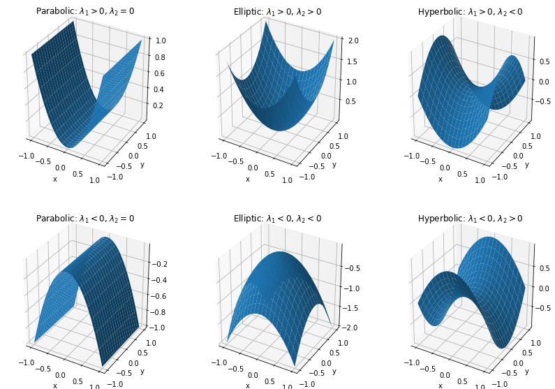

```python
# Choose eigenvalues of surfaces and plot titles
lambdas = [[1.0, 0.0], [1.0, 1.0], [1.0, -1.0], [-1.0, 0.0], [-1.0, -1.0], [-1.0, 1.0]]
titles = [r'Parabolic: $\lambda_1 > 0$, $\lambda_2 = 0$',
          r'Elliptic: $\lambda_1 > 0$, $\lambda_2 > 0$',
          r'Hyperbolic: $\lambda_1 > 0$, $\lambda_2 < 0$',
          r'Parabolic: $\lambda_1 < 0$, $\lambda_2 = 0$',
          r'Elliptic: $\lambda_1 < 0$, $\lambda_2 < 0$',
          r'Hyperbolic: $\lambda_1 < 0$, $\lambda_2 > 0$']

# Define grid
x, y = np.meshgrid(np.linspace(-1.0, 1.0, 20), np.linspace(-1.0, 1.0, 20))

# Plot surfaces defined by lambda1 * x^2 + lambda2 * y^2
plt.rcParams['figure.figsize'] = [14, 10]
fig = plt.figure()
for i in range(len(lambdas)):
    lmbda = lambdas[i]
    title = titles[i]
    intensity = lmbda[0] * x ** 2 + lmbda[1] * y ** 2
    ax = fig.add_subplot(2, 3, i + 1, projection='3d')
    ax.plot_surface(x, y, intensity)
    plt.xlabel('x')
    plt.ylabel('y')
    plt.title(title)
```

If we interpret the intensity function $I(x,y)$ as a surface, then the eigenvalues of ${\cal H}(x,y)$ correspond to the *principal curvatures* of the surface at the point $(x,y)$ , meaning the values of maximum and minimum curvature at that point. (The eigenvectors are orthogonal and correspond to the directions of maximum and minimum curvature.)

The product of principal curvatures (equal to $\mbox{det}({\cal H})$) is termed the *Gaussian curvature* and their average (equal to $\frac{1}{2}\mbox{trace}({\cal H})$) is the *mean curvature*.

**a.** Use the image `./data/calib_right.bmp`. Convert it to a grayscale image of data type `numpy.float32` and display it. Assuming the mean and Gaussian curvature (denoted $H(x,y)$ and $K(x,y)$, respectively) have been computed at each point on the image plane, write an expression for "cornerness" $C(x,y)$ in terms of $H$ and/or $K$ that will yield a large response at the corners of the checker pattern and a small response elsewhere.

### Answer:

From class, we see that the definition of a corner is one in which the intensities of the image change very rapidly if we move a window containing the corner in two orthogonal directions. That is, we want the intensity surface to gemetrically look similar to the middle elliptic curvatures in the diagram.

So, we will use the following function to detect corners:

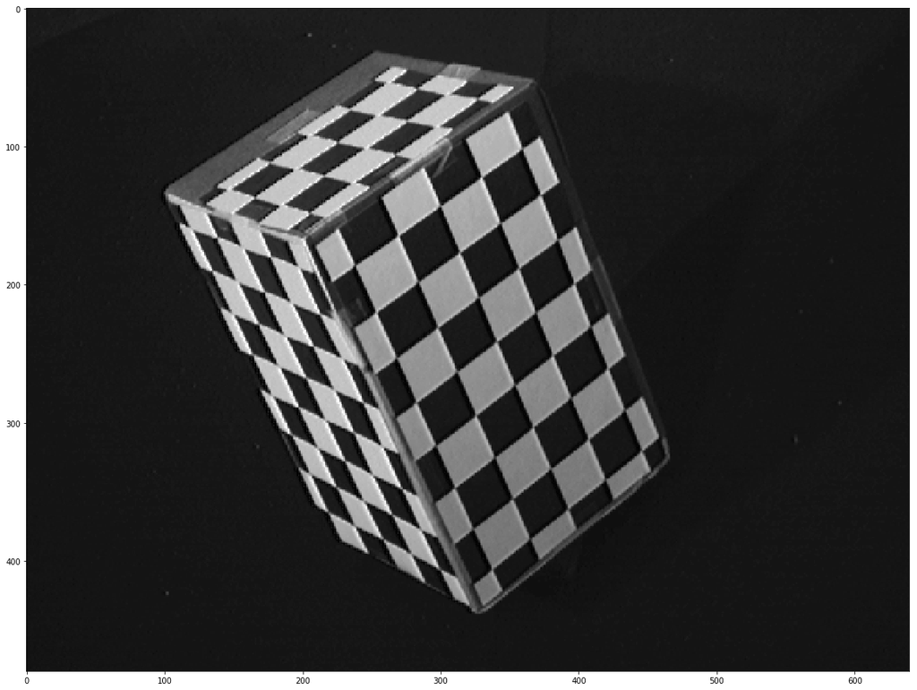

```python
# read in image
image = cv2.imread('data/calib_right.bmp')
im = cv2.cvtColor(image, cv2.COLOR_BGR2GRAY)

# convert image to grayscale and display
fig = plt.figure( figsize=(20, 20))
ax = fig.add_subplot(111)
ax.imshow(im, cmap='gray')
```

**b.** Write a function `cornerness()` that computes your function $C(x,y)$ from part (a) given a grayscale image `im` and a smoothing parameter `sigma` ($\sigma$) used to estimate the second derivatives of the image. It may also take other parameters you defined in part (a). This function should contain no loops. (Also, see Hints and Information below regarding discrete approximations to second derivatives.)

Run this function on the grayscale version of `./data/calib_right.bmp` using $\sigma=2$ and your choice of other parameters, and display the function $C(x,y)$ as a grayscale image (using the appropriate color map). Make sure to properly display $C(x, y)$, for example by rescaling it to the range $[0, 1]$ or by using the `vmin` and `vmax` inputs to `matplotlib.pyplot.imshow()`.

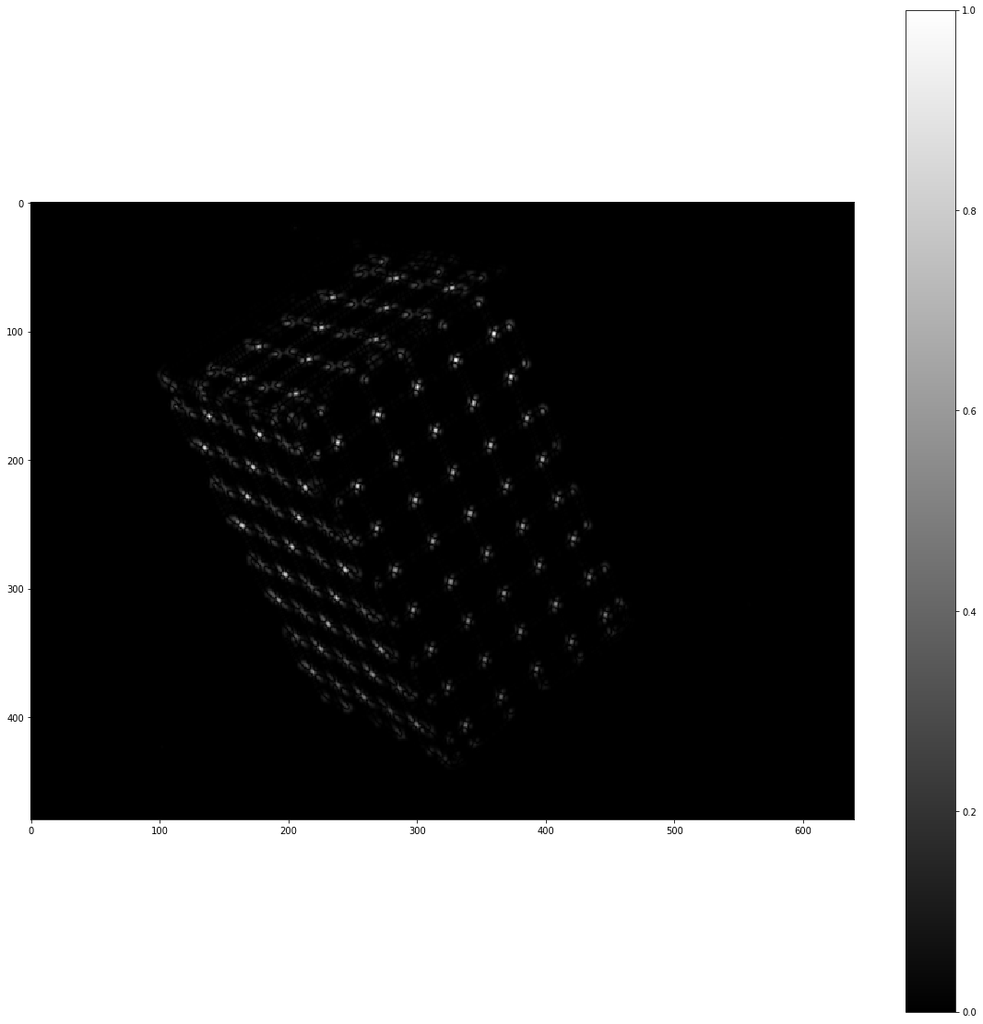

```python
import math

# create kernels for Ixx, Iyy, Ixy filters
def deriv(sigma):
    # Use an odd-size square window with length greater than 5 times sigma
    w = 2 * np.floor(7 * sigma / 2) + 1
    x, y = np.meshgrid(np.arange(-(w-1)/2, (w-1)/2 + 1),
                       np.arange(-(w-1)/2, (w-1)/2 + 1))

    # calculate Gaussian distribution
    r = x ** 2 + y ** 2
    Gauss = (np.exp(-r/(2*sigma**2))) / (2*(math.pi)*sigma**2)

    # Caluclate Ixx, Iyy, Ixy filters
    X_filt = ((x**2 - sigma**2)/sigma**4) * Gauss
    Y_filt = ((y**2 - sigma**2)/(sigma**4)) * Gauss
    XY_filt = (x*y)/(sigma**4) * Gauss

    return X_filt, Y_filt, XY_filt

def cornerness(image, sigma):

    # get Ixx, Iyy, Ixy filter values
    X_filt, Y_filt, XY_filt = deriv(sigma)

    # convolve filters with image to get actual Ixx, Iyy, Ixy values
    Ixx = scipy.signal.convolve2d(image, X_filt, 'same', boundary='symm')
    Iyy = scipy.signal.convolve2d(image, Y_filt, 'same', boundary='symm')
    Ixy = scipy.signal.convolve2d(image, XY_filt, 'same', boundary='symm')

    # calculate determinant and trace
    det = Ixx * Iyy - Ixy**2
    trace = Ixx + Iyy

    # return C(x, y)
    return det

# calculate cornerness over image and normalize
C = cornerness(im, 2)
C = np.abs(C)
C = C - C.min()
C = C/C.max()

# display corners
fig = plt.figure(figsize=(20, 20))
ax = fig.add_subplot(111)
im2 = ax.imshow(np.abs(C), cmap="gray")
plt.colorbar(im2)
```

### Answer:

(I'm not really sure what this answer spot is for; there was nothing in this question portion asking for a written response.)

**c.** Write a function `nonmax_suppression(C)` that returns a 2D array `Co` the same size as `C` that satisfies the following rule: $C_o(x,y)=C(x,y)$ if $C(x,y)$ is maximal in its local $3\times 3$ neighborhood, and $C_o(x,y)=0$ otherwise (see Hints and Information below about morpholotical operators, and especially dilation).

Display the grayscale version of the image `./data/calib_right.bmp` and superimpose a plot of the points $(x,y)$ that satisfy $C_o(x,y) > \texttt{threshold}$, where `threshold` is manually selected to provide a reasonable balance of false detections and missed detections. **Make sure the points are marked clearly in your submission.**

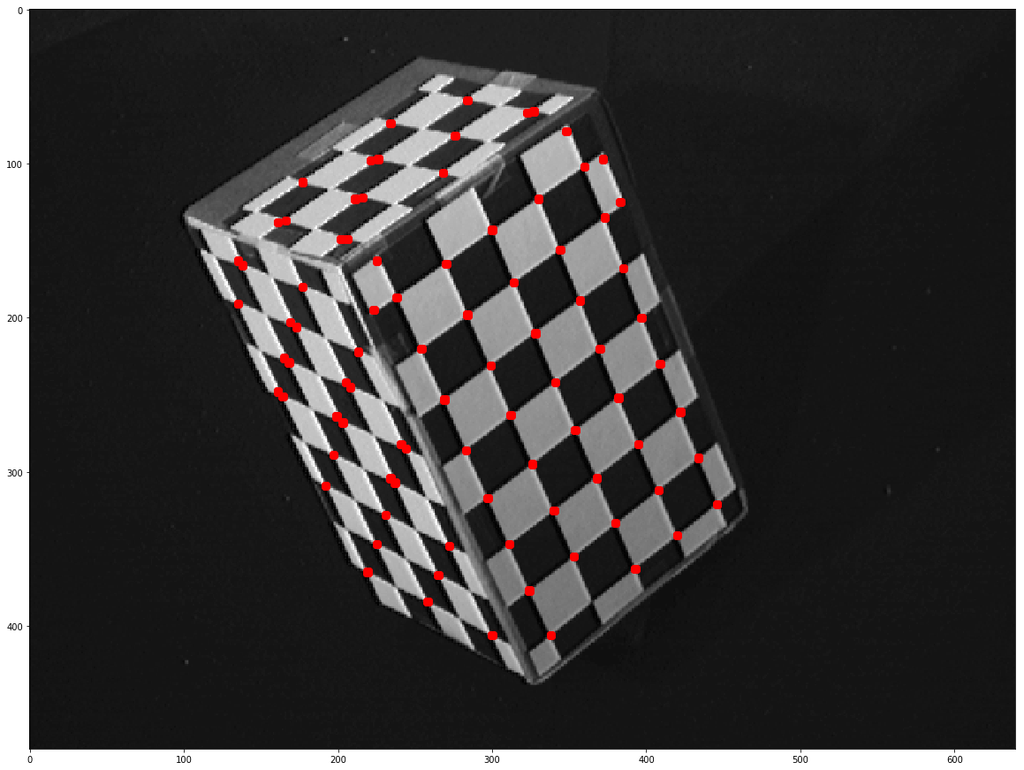

```python
# calculate nonmax suppression
def nonmax_suppression(C):

    # determine if pixel is local maximum
    def is_local_max(i, j, im):
        if i == 0 or j == 0 or i == im.shape[0] - 1 or j == im.shape[0] - 1:
            return 0

        slce = im[i-1:i+2, j-1:j+2]
        if np.argmax(slce) == 4:
            return im[i][j]
        return 0

    # filter all local maxima
    C0 = np.array([[is_local_max(i, j, C) for j in range(C.shape[1])] for i in range(C.shape[0])])
    return C0

# dilate image to remove false positives
C0 = cv2.dilate(nonmax_suppression(C), None)

# set threshold to 0.4 and filter(seems to work well in practice)
thres = 0.4
points = np.array([[i, j] for i in range(C0.shape[0]) for j in range(C0.shape[1]) if C0[i,j] > thres])

# display image and points
fig = plt.figure(figsize=(20, 20))
ax = fig.add_subplot(111)
ax.imshow(im, cmap="gray")
plt.scatter(points[:,1], points[:,0], c='r')
plt.show()
```

\

## Question 4 (10 points)

The continuous convolution of two functions $f\left(x\right)$ and $g\left(x\right)$ is given by: \begin{equation*} \left(f * g \right)\left(x\right) = \int_{-\infty}^{\infty} f\left(y\right) g\left(x - y\right) dy. \end{equation*} The Gaussian function at scale $s$ is defined as: \begin{equation*} G_s \left(x\right) = \frac{1}{\sqrt{2 \pi s}} \exp\left(-\frac{x^2}{2s}\right), \end{equation*} and has the property that: \begin{equation*} \int_{-\infty}^{\infty} G_s\left(x\right) dx = 1. \end{equation*} Prove that this class of functions satisfies the *semigroup property*: the convolution of one Gaussian with another produces a third Gaussian with scale equal to their sum, or: \begin{equation*} \left(G_{s_1} \ast G_{s_2}\right) \left(x\right) = G_{s_1 + s_2} \left(x\right). \end{equation*}

### Answer:

We know that convolution in the time domain is equivalent to multiplication in the frequency domain; thus, we begin by calculating the Fourier transform of the Gaussian function. (Resource: http://www.cse.yorku.ca/~kosta/CompVis_Notes/fourier_transform_Gaussian.pdf)

Using the following form of the Fourier Transform:

$$ F(w) = \int_{-\infty}^{\infty}g(x)e^{-i\omega x}dx$$

We write F(f(x)), with x a generic Gaussian function of scale $\sigma$:

$$ F(\omega) = \int_{-\infty}^{\infty} \frac{1}{\sqrt{2\pi\sigma}} e^{\frac{-x^2}{2\sigma}}e^{-i\omega x}dx$$

To evaluate, we use integreation by parts. We first take the derivative of the expression with respect to $\omega$:

$$ \frac{dG(\omega)}{d\omega} = \int_{-\infty}^{\infty}\frac{-ix}{\sqrt{2\pi\sigma}}e^{-x^2/2\sigma}e^{-iwx}dx$$

We then use the following values for our integration by parts formula:

$$ \begin{array}{cc} u = e^{-i\omega x} & du = -i\omega e^{-i\omega x}dx \\ dv=\frac{-x}{\sigma\sqrt{2\pi\sigma}}ie^{-x^2/2\sigma} & v=\frac{1}{\sqrt{2\pi\sigma}}ie^{-x^2/2\sigma}\end{array}$$

We then see that:

$$ \int u\cdot dv = \int \frac{-ix}{\sigma \sqrt{2\pi\sigma}}e^{-x^2/2\sigma} e^{-i\omega x} dx$$

And thus, using the derivation above, $\frac{1}{\sigma}\frac{dF(\omega)}{d\omega} = \int u\cdot dv$. Then, using the integration by parts formula, we have:

$$ \frac{1}{\sigma}\frac{dF(\omega)}{d\omega} = e^{-i\omega x}\frac{1}{\sqrt{2\pi\sigma}}ie^{-x^2/2\sigma} - \int_{-\infty}^{\infty}\frac{1}{\sqrt{2\pi\sigma}}ie^{-x^2/2\sigma}iwe^{-iwx}dx$$

The first term will evaluate to 0 in the infinite limit, so we have:

$$ \frac{1}{\sigma}\frac{dF(\omega)}{d\omega} = - w \int_{-\infty}^{\infty}\frac{1}{\sqrt{2\pi}\sigma}e^{-x^2/2\sigma}e^{-iwx}$$$$ \frac{dF(\omega)}{d\omega} = - \omega \sigma\int_{-\infty}^{\infty}\frac{1}{\sqrt{2\pi\sigma}}e^{-x^2/2\sigma}e^{-iwx}$$$$ \frac{dF(\omega)}{d\omega} = - \omega \sigma\int_{-\infty}^{\infty} f(x)e^{-i\omega x}dx$$$$\frac{dF(\omega)}{d\omega} = -\omega\sigma F(x) $$

We see this is a differential equation, with standard form:

$$ F(x) = F(0)e^{-\frac{\omega^2\sigma}{2}}$$

We then consider the value $F(0)$:

$$ F(0) = \int_{-\infty}^{\infty}f(x)e^{-i\cdot 0\cdot x}dx$$$$ F(0) = \int_{-\infty}^{\infty}f(x)dx = 1$$

So, we are left with the Fourier transform for the Gaussian:

$$ F(x) = e^{-\frac{\omega^2\sigma}{2}}$$

We then consider the convolution of the Gaussians described above. We see that the convolution is equivalent to multiplication in the frequency domain. So, we calculate the two Fourier transforms:

$$ F(G_{s_1}(x)) = e^{-\frac{\omega^2s_1}{2}}$$$$ F(G_{s_2}(x)) = e^{-\frac{\omega^2s_2}{2}}$$

Multiplying these values gives:

$$ e^{-\frac{\omega^2s_1}{2}}e^{-\frac{\omega^2s_2}{2}} = e^{-\frac{\omega^2(s_1 + s_2)}{2}} $$

We see that $e^{\frac{\omega^2(s_1 + s_2)}{2}}$ is the Fourier transform of a Gaussian with standard deviation with scale s_1 + s_2$, and the inverse transform will give us:

$$ G_{s_1 + s_2} = \frac{1}{\sqrt{2\pi(s_1 + s_2)}}e^{\frac{-x^2}{2(s_1 + s_2)}}$$

Thus, we conclude that the convolution of two Gaussians with scales $s_1, s_2$, respectively, is Gaussian with scale $s_1 + s_2$. $\blacksquare$

## Hints and Information

- Robustly estimating the second derivatives of a function on a two dimensional domain is achieved by pre-filtering the function with a Gaussian kernel. Since convolution is associative, the smoothing and differentiation can be accomplished in a single step using filters that are second derivatives of a Gaussian. For example, the filter for computing the second derivative in the horizontal direction $I_{xx}$ is \begin{equation*} \frac{\partial^2}{\partial x^2}G(x,y;\sigma)=\left(\frac{x^2-\sigma^2}{\sigma^4}\right)G(x,y;\sigma), \end{equation*} where, as usual, the parameter $\sigma$ defines the "scale" of the derivative, and a discrete window width of about $5\sigma$ to $7\sigma$ is sufficient to accurately represent this continuous filter function. You should be able to write corresponding expressions for $I_{yy}$ and $I_{xy}=I_{yx}$.
- One way to think of convolution is as computing sums of weighted intensity values in a neighborhood around each pixel, with the shape of the neighborhood determined by the shape of the kernel, and the weights by its values. We can then define generalizations of convolution by replacing the sum operation with other functions.  
  One such class of (non-linear) generalizations is *morphological operators*, where the sum is replaced by an ordinal relationship: after weighting the intensity values, compute their max, min, median, or their $k$-th largest value for any integer $k$. This last case is called *$k$-ordinal filtering*. The case of max, which is equivalent to $1$-ordinal filtering, is known as *dilation*. Finally, the case of min, equivalent to setting $k$ equal to the neighborhood size, is known as *erosion*. For more on morphological operators, you can read Section 3.3.2 of Szeliski.  
  As with linear convolution, there are several efficient algorithms for computing morphological operators, many of which are implemented in OpenCV. Two-dimensional dilation in particular is provided by the function `cv2.dilate()`. You can find out more information in [OpenCV's morphological operation tutorial](http://docs.opencv.org/trunk/d9/d61/tutorial_py_morphological_ops.html).